# Analysis on Sanger sequencing of mixed culture using CASEU

Chang-Yu Chang

2021-01-28

# Goal

- To determine the relative abundance of of ambiguous pairs in competitive assays.
- Use CASEU packages to analyse the Sanger sequencing of mixture culture.
- Sanger sequencing protocol preparation. Experimental protocol files are saved in folder `Google Drive/Protocol`
- Once we got the mixture Sanger sequences back, we implement analysis by using `CASEU` (Compositional analysis by Sanger electropherogram unmixing), an R package desgined for quantifying relative abundance of Sanger sequences mixture. [source code](https://bitbucket.org/DattaManoshi/caseu). Install `CASEU` from bitbucket.

```r
devtools::install_bitbucket('dattamanoshi/caseu') # Install CASEU package
library(CASEU)
```

# Test on example data

Test the example code and data.

Fit Sanger sequences of a mixed culture of four strains. This step may take a few seconds.

```r
data('fourStrainExpt') # load an example dataset
results <-
  fitSangerMixture(mixture=fourStrainExpt$mixture, # mixture
  components = fourStrainExpt$components, # Four individual 16S sequences
  verbose=TRUE)

save(results, file = here::here("data/temp/CASEU_test_results1.Rdata"))
```

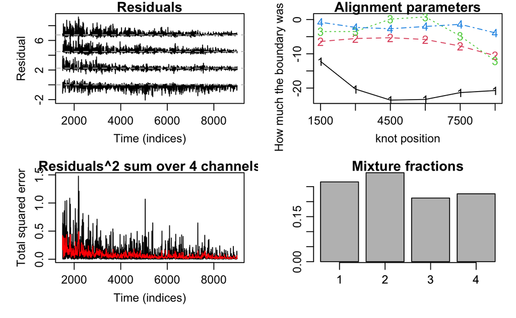

Fitted mixture sanger electropherogram output

[output not shown]

# CASEU pilot1

The plate layout of PCR plate and list of samples are specified in `output/protocol/protocol_20190813_Sanger_seq_prep.pdf`.

| Sample # | DNA Name | Length (bp) | Concentration (ng/uL) | Primer | Difficult Template | Notes | Is Empty |
| --- | --- | --- | --- | --- | --- | --- | --- |
| 1 | A | 1000 | 0.83 | 27F | NA | NA | NA |
| 2 | B | 1000 | 0.83 | 27F | NA | NA | NA |
| 3 | C | 1000 | 0.83 | 27F | NA | NA | NA |
| 4 | D | 1000 | 0.83 | 27F | NA | NA | NA |
| 5 | OD_1_99_AB | 1000 | 0.83 | 27F | NA | NA | NA |
| 6 | OD_1_99_AC | 1000 | 0.83 | 27F | NA | NA | NA |
| 7 | OD_1_99_AD | 1000 | 0.83 | 27F | NA | NA | NA |
| 8 | OD_1_99_CD | 1000 | 0.83 | 27F | NA | NA | NA |
| 9 | OD_5_95_AB | 1000 | 0.83 | 27F | NA | NA | NA |
| 10 | OD_5_95_AC | 1000 | 0.83 | 27F | NA | NA | NA |

[output cut: 19 more lines]

The isolates used in this round is from the list below.

isolates

| Isolate | Code | Taxa |
| --- | --- | --- |
| C11R1 isolate 1 | A | Pseudomonas |
| C1R7 isolate 2 | B | Pseudomonas |
| C1R7 isolate 1 | C | Enterobacter |
| C1R7 isolate 7 | D | Raoultella |

Read trace matrices for isolates and mixtures

# CASEU pilot2

The plate layout of PCR plate and list of samples are specified in `output/protocol/protocol_20190813_Sanger_seq_prep.pdf`. There are 32 samples from pairwise competition and 16 samples from control. Also read Sylvie’s data.

Isolates A B C D in control are the isolates below.

| Isolate | Code | Taxa |
| --- | --- | --- |
| C11R1 isolate 1 | A | Pseudomonas |
| C1R7 isolate 2 | B | Pseudomonas |
| C1R7 isolate 1 | C | Enterobacter |
| C1R7 isolate 7 | D | Raoultella |

## Control pairs

In the 12 control synthetic pairs that were made of 4 isolates, compare these pairs’ OD frequencies, colony counts, and CASEU predictions.

Read CASEU predicted frequencies and colony count frequencies in the 12 control pairs.

Join the CASEU predicted result of control pairs in `CASEU_pilot2` with the plating result in `CASEU_pilot2_plating`. The pair CYC_control_50_50_CD has a lot colonies and the colony count of C is just approximaton (n=300)

## Outcome of pairwise competition

There are 24 pairs of C11R1 been sequenced in CASEU pilot2.

# CASEU pilot3

The plate layout of PCR plate and list of samples are specified in `output/protocol/protocol_20190923_SequalPrep_Sanger_prep.pdf`.

| Sample # | DNA Name | Length (bp) | Concentration (ng/uL) | Primer |
| --- | --- | --- | --- | --- |
| 1 | C7R1_50_50_3_4 | 1000 | 0.83 | 27F |
| 2 | C7R1_95_5_3_4 | 1000 | 0.83 | 27F |
| 3 | C7R1_5_95_3_4 | 1000 | 0.83 | 27F |
| 4 | C11R2_50_50_2_8 | 1000 | 0.83 | 27F |
| 5 | C11R2_50_50_3_7 | 1000 | 0.83 | 27F |
| 6 | C11R2_50_50_3_12 | 1000 | 0.83 | 27F |
| 7 | C11R2_50_50_6_11 | 1000 | 0.83 | 27F |
| 8 | C11R2_50_50_7_12 | 1000 | 0.83 | 27F |
| 9 | C11R2_95_5_2_8 | 1000 | 0.83 | 27F |
| 10 | C11R2_95_5_3_7 | 1000 | 0.83 | 27F |

[output cut: 54 more lines]

Read trace matrices for isolates and mixtures

# CASEU pilot4

The plate layout of PCR plate and list of samples are specified in `output/protocol/protocol_20191007_Sanger_seq_prep.pdf`.

| Sample # | DNA Name | Length (bp) | Concentration (ng/uL) | Primer |
| --- | --- | --- | --- | --- |
| 1 | C8R4_50_50_1_3 | 1000 | 0.83 | 27F |
| 2 | C8R4_95_5_1_3 | 1000 | 0.83 | 27F |
| 3 | C8R4_5_95_1_3 | 1000 | 0.83 | 27F |
| 4 | C2R6_50_50_1_3 | 1000 | 0.83 | 27F |
| 5 | C7R1_50_50_1_3 | 1000 | 0.83 | 27F |
| 6 | C7R1_50_50_1_4 | 1000 | 0.83 | 27F |
| 7 | C2R8_50_50_3_4 | 1000 | 0.83 | 27F |
| 8 | C2R6_95_5_1_3 | 1000 | 0.83 | 27F |
| 9 | C7R1_95_5_1_3 | 1000 | 0.83 | 27F |
| 10 | C7R1_95_5_1_4 | 1000 | 0.83 | 27F |

[output cut: 31 more lines]

Read trace matrices for isolates and mixtures